# ЗАНЯТИЕ 13. Библиотека Scikit-learn. Обучение с учителем и без учителя[1]

[1] ☝🙂 Данное занятие разработано на основе источников [22–26], среди которых: есть официальная документация  scikit-learn и 2 русскоязычных статьи.

## Цели занятия

Получение представления о функциональности, доступных методах и объектах библиотеки `scikit-learn`. Изучение основных принципов практической работы с ними для реализации математических алгоритмов.

Рассмотрение основных положений машинного обучения с учителем и без учителя: метод k–средних, линейная регрессия и деревья решений.

## Порядок выполнения работы

### Введение

Библиотека `scikit-learn` – самый распространенный выбор для решения задач классического машинного обучения. Она предоставляет широкий выбор алгоритмов обучения с учителем и без учителя.

Обучение с учителем предполагает наличие размеченного датасета, в котором известно значение целевого признака. В то время как обучение без учителя не предполагает наличия разметки в датасете — требуется научиться извлекать полезную информацию из произвольных данных.

Одно из основных преимуществ библиотеки состоит в том, что она работает на основе нескольких распространенных математических библиотек, и легко интегрирует их друг с другом. Еще одним преимуществом является широкое сообщество и подробная документация.

`Scikit-learn` широко используется для промышленных систем, в которых применяются алгоритмы классического машинного обучения, для исследований, а так же популярна у новичков, которые только делают первые шаги в области машинного обучения.

Для работы `scikit-learn` используются представленные ниже популярные библиотеки. Почти все они уже были рассмотрены ранее:

- `NumPy` – математические операции и операции над массивами;
- `SciPy` – научно–технические вычисления;
- `Matplotlib` – визуализация данных;
- `SymPy` – символьная математика;
- `Pandas` – обработка, манипуляция и анализ данных.

`Scikit-learn` специализируется на алгоритмах машинного обучения с учителем и без учителя.

### Обучение с учителем

Обучение с учителем (англ. Supervised learning) – это один из способов машинного обучения, в ходе которого испытуемая система принудительно обучается с помощью примеров «стимул–реакция». К обучению с учителем относятся задачи классификации и регрессии.

Классификация – система группировки объектов исследования или наблюдения в соответствии с их общими признаками. При классификации происходит предсказание признака, множество допустимых значений которого ограничено.

Регрессия – выявление зависимости между случайными переменными и математическим выражением, отражающим связь между зависимой переменной *y* и независимыми переменными *x*<sub>*i*</sub> при условии, что это выражение будет иметь статистическую значимость. В отличие от чисто функциональной зависимости *y* = *f*(*x*<sub>*i*</sub>), когда каждому значению независимой переменной *x*<sub>*i*</sub> соответствует одно определённое значение величины *y*, при регрессионной связи одному и тому же значению *x*<sub>*i*</sub> могут соответствовать в зависимости от случая различные значения величины *y*.

Стоит отметить, что существует подвид (т.е. частный случай) обучения с учителем, называемый «обучение с подкреплением». При данном типе обучения, испытуемая система (называемая агентом) обучается, взаимодействуя с некоторой средой, которая дает модели отклик на принятые решения. Отклик – это обратная связь. При этом агент не имеет никакой информации о среде, и способен обучатся только посредством получения обратной связи от воздействия на неё.

### Обучение без учителя

Обучение без учителя (самообучение, спонтанное обучение, англ. Unsupervised learning) — один из способов машинного обучения, при котором испытуемая система спонтанно обучается выполнять поставленную задачу без вмешательства со стороны экспериментатора.

Как правило, оно пригодно только для задач, в которых известны описания множества объектов (т.е. существуют обучающие выборки), и требуется обнаружить внутренние взаимосвязи или закономерности, существующие между объектами.

Примерами обучения без учителя являются:

- кластеризация – задача группировки множества объектов на подмножества (кластеры) таким образом, чтобы объекты из одного кластера были более похожи друг на друга, чем на объекты из других кластеров по какому-либо критерию.
- снижение размерности – представление данных в пространстве меньшей размерности с минимальными потерями полезной информации. Обычно в его основе лежит метод главных компонент).
- выявление аномалий – это опознавание во время интеллектуального анализа данных редких данных, событий или наблюдений, которые вызывают подозрения ввиду существенного отличия от большей части данных.

### Функциональность Scikit-learn

Библиотека `scikit-learn` реализует следующие основные методы:

- **Линейные:** модели, задача которых построить разделяющую или аппроксимирующую гиперплоскость (для классификации и регрессии соответственно).
- **Метрические:** модели, которые вычисляют расстояние по одной из метрик между объектами выборки, и принимают решения в зависимости от этого расстояния (например, метод K–ближайших соседей).
- **Деревья решений:** обучение моделей, базирующихся на множестве условий, оптимально выбранных для решения задачи.
- **Ансамблевые методы:** методы, основанные на деревьях решений, которые комбинируют мощь множества деревьев, и таким образом повышают их качество работы, а также позволяют производить отбор признаков (бустинг, бэггинг, случайный лес, мажоритарное голосование).
- **Нейронные сети:** комплексный нелинейный метод для задач регрессии и классификации.
- **Метод опорных векторов** (англ. support vector machine, SVM): нелинейный метод, который обучается определять границы принятия решений.
- **Наивный Байес:** прямое вероятностное моделирование для задач классификации.
- **Метод главных компонент** (англ. principal component analysis, PCA): линейный метод понижения размерности и отбора признаков.
- **Стохастическое вложение соседей с t–распределением** (англ. t-distributed Stochastic Neighbor Embedding, t-SNE): нелинейный метод понижения размерности.
- **K–средних:** самый распространенный метод для кластеризации, требующий на вход число кластеров, по которым должны быть распределены данные.
- **Кросс–валидация**: метод, при котором для обучения используется весь датасет (в отличие от разбиения на выборки `train/test`), однако обучение происходит многократно, и в качестве валидационной выборки на каждом шаге выступают разные части датасета. Итоговый результат является усреднением полученных результатов.
- **Поиск по сетке** (англ. Grid Search): метод для нахождения оптимальных гиперпараметров[2] модели путем построения сетки из значений гиперпараметров и последовательного обучения моделей со всеми возможными комбинациями гиперпараметров из сетки.

[2] ☝🙂 Гиперпараметр – это параметр, который не настраивается во время обучения модели. Пример гиперпараметра – шаг градиентного спуска, он задается перед обучением. Пример параметров – веса градиентного спуска, они изменяются и настраиваются во время обучения.

Выше представлен лишь базовый список. Помимо перечисленного, `scikit-learn` содержит функции для расчета значений метрик, выбора моделей, предварительной обработки данных (препроцессинга) и другие. Полный список доступен в официальной документации по url: https://scikit-learn.org/stable/user_guide.html. Так же на официальном сайте доступно большое количество примеров, которые можно скачать единым архивом, открыть в `JupyterLab` и изучить: https://scikit-learn.org/stable/auto_examples/index.html [3].

[3] ☝🙂 Все примеры при помощи кнопки «`launch binder`» можно запустить в облачном `Jupyter` блокноте, без каких-либо дополнительных манипуляций с окружением – прямо с сайта–документации. Стоит отметить, что наличие готовых к запуску примеров – это редкость. Возможно, из описанных в книге библиотек, `scikit-learn` имеет наиболее доступную к пониманию документацию. Так же доступен блокнот для распознавания рукописных цифр посредством этой библиотеки – аналог уже рассмотренного решения, в котором использовался `TensoFlow Keras`.

Давайте рассмотрим несколько базовых примеров работы с данной библиотекой.

### Кластерный анализ

Кластерный анализ или кластеризация – это задача группировки набора объектов таким образом, чтобы объекты в одной группе (называемой кластером) были более похожи (в некотором смысле) друг на друга, чем на объекты в других группах (кластерах). Это основная задача исследовательского анализа данных и общий метод статистического анализа данных, используемый во многих областях, включая распознавание образов, анализ изображений, поиск информации, биоинформатику, сжатие данных, компьютерную графику и машинное обучение.

Ниже показан результат кластерного анализа по признаку геометрического положения квадратов (Рис. 1). Принадлежность к одному из трёх кластеров отмечена цветом.

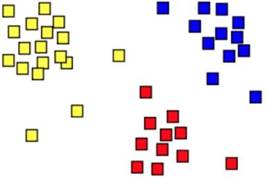

Рис. 1. Кластеризация на 3 группы

Кластеризация немаркированных данных, т.е. когда заранее не известно к какому классу принадлежат данные, может выполняться с помощью модуля `sklearn.cluster`.

#### Обзор доступных методов кластеризации[4]

[4] ☝🙂 Полный обзор с примерами доступен на английском языке по url: https://scikit-learn.org/stable/modules/clustering.html .

В таблице ниже представлены основные доступные методы кластеризации с их краткими характеристиками и описанием (Таблица 1). На рисунке после данной таблицы представлено графическое сравнение результата работы данных методов (Рис. 2). На рисунке названия методов представлены на английском языке, т.к. столбцы рисунка соответствуют строкам таблицы.

Таблица 1. Доступные методы кластеризации

**Название метода**

**Параметры**

**Масштабируемость**

**Вариант использования**

**Геометрия**

К–средние

количество кластеров

Очень большое кол–во примеров, среднее кол–во кластеров (при пакетном обучении MiniBatch)

Универсальный, плоская геометрия, не слишком много кластеров, индуктивное метод[^1]

Расстояния между точками

Метод распространения близости

демпфирование, схожесть

Не масштабируется с помощью кол–ва примеров

Множество кластеров, неравномерные размеры кластеров, неплоская геометрия, индуктивный метод

Длина графа (напр., до ближайшего соседа)

Сдвиг среднего значения

пропускная способность

Не масштабируется с помощью кол–ва примеров

Множество кластеров, неравномерный размер кластера, неплоская геометрия, индуктивный метод

Расстояния между точками

Спектральная кластеризация

количество кластеров

Среднее кол–во примеров, и малое кол–во кластеров

Мало кластеров, одинаковые размеры кластеров, неплоская геометрия, трансдуктивный метод[^2]

Длина графа

Иерархическая кластеризация

количество кластеров или порог расстояния

Большое кол–во примеров и кластеров

Много кластеров, возможны ограниченные зависимости между данными, трансдуктивный метод

Расстояния между точками

Агломеративная кластеризация

количество кластеров/порог, тип связи,

Большое кол–во примеров и кластеров

Множество кластеров, возможны ограниченные зависимости, неевклидовы расстояния[^3], трансдуктивный метод

Любое попарное расстояние

DBSCAN

Близость соседа

Очень большое кол–во примеров, и среднее кол–во кластеров

Неплоская геометрия, неодинаковые размеры кластеров, трансдуктивный метод

Расстояния между ближайшими точками

Оптический метод кластеризации

минимальное членство в кластере

Большое кол–во примеров и кластеров

Неплоская геометрия, неравномерные размеры кластеров или их переменная плотность, трансдуктивный метод

Расстояния между точками

Гауссовские смеси

много параметров

Не масштабируется

Плоская геометрия, подходит для оценки плотности, индуктивная

Расстояние Махаланобиса до центров

BIRCH

фактор ветвления, порог, кластеризатор

Большое кол–во примеров и кластеров

Большой набор данных, удаление выбросов, сокращение данных, индуктивный

Евклидово расстояние между точками

[^1]: ☝🙂 Индуктивный метод – обучение по прецедентам, или индуктивное обучение, основано на выявлении общих эмпирических закономерностей в данных.
[^2]: ☝🙂 Трансдуктивный метод – обучение с частичным привлечением учителя, когда прогноз предполагается делать только для частной тестовой выборки на основе частной обучающей выборки (т.е. без систематичности предсказаний). На основе одной песни можно сгенерировать похожую.
[^3]: ☝🙂 Обычно используются евклидовы расстояния (евклидова метрика) между векторами, вычисляемое по теореме Пифагора. К неевклидовым относятся следующие расстояния: манхэттенское, Минковского, Махаланобис, косинусное сходство, жаккардовое – и другие. Использование конкретных типов расстояния зависит от характера данных – размер, тип и др. (например, если необходимо определять схожесть между двумя текстами, то используется косинусное сходство).

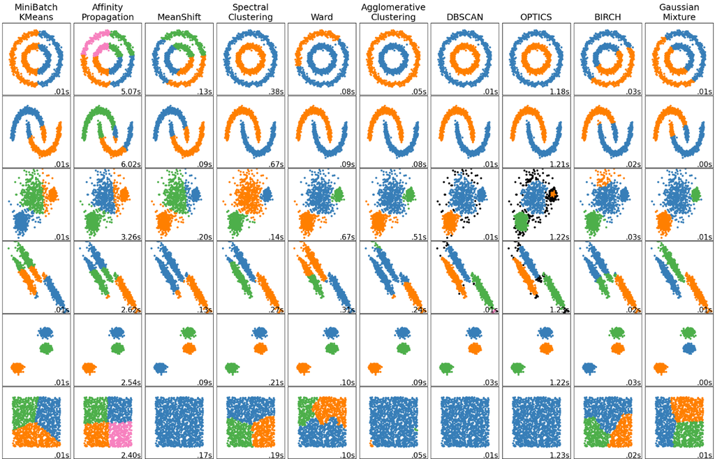

Рис. 2. Различные методы кластеризации

Давайте рассмотрим наиболее часто применяющийся алгоритм кластеризации: метод К–средних.

#### К–средних (K-means)

Алгоритм К–средних делит набор данных на непересекающиеся кластеры, каждый из которых описывается средним центром массы в кластере. Средние значения обычно называют «центроидами» кластера.

Действие алгоритма таково, что он стремится минимизировать суммарное квадратичное отклонение точек кластеров от центров этих кластеров (формула 33). Это так же называется инерцией.

| $$\sum_{i = 0}^{n}{\min_{\mu \in С}\left( \left\\| x_{i} - \mu_{j} \right\\|^{2} \right)}$$ | (33) |
| --- | --- |

где $n$ – число кластеров; $x$ – точка данных; i=1, 2, ...; $\mu_{j}$ — центры масс всех векторов $x$ из множества непересекающихся кластеров $С$.

По аналогии с методом главных компонент центры кластеров называются также главными точками, а сам метод называется методом главных точек и включается в общую теорию главных объектов, обеспечивающих наилучшую аппроксимацию данных.

Обратим внимание, что центр масс *μ*<sub>*j*</sub> как правило, не совпадает с точками данных, хотя они и живут в одном пространстве.

Инерцию можно определить как меру того, насколько кластеры внутренне связаны. Данный алгоритм обладает следующими недостатками:

- Инерция предполагает, что кластеры выпуклые и изотропные, что не всегда так. Алгоритм плохо реагирует на удлиненные кластеры или связи неправильной формы.
- Инерция – это не нормализованная метрика: нам всего лишь известно, что более низкие значения лучше, а ноль – оптимально. Но в очень многомерных пространствах евклидовы расстояния имеют тенденцию становиться раздутыми (это пример так называемого «проклятия размерности»). Выполнение алгоритма уменьшения размерности, такого как анализ главных компонентов (PCA) перед кластеризацией k–средних, может облегчить эту проблему и ускорить вычисления. PCA так же доступен в scikit-learn.

#### Пример кластеризации K-средних

В этом примере мы рассмотрим, как реализовать кластеризацию методом K–средних с помощью `scikit-learn` и `pandas`. Начнем с подключения необходимых модулей:

```python
from sklearn.cluster import KMeans
import pandas as pd
import matplotlib.pyplot as plt
from matplotlib import style
%matplotlib inline
```

#### Создание исходных данных

Первый шаг – это создать исходные данные вручную, или же сгенерировать их. Мы создадим данные вручную – пусть это будет двухмерный массив значений x и y. В этом наборе данных данные имеют только две оси (но метод K–средних может использоваться с любым количеством осей):

```
     x     y
0  1.0   2.0
1  5.0   8.0
2  1.5   1.8
3  8.0   8.0
4  1.0   0.6
5  9.0  11.0
```

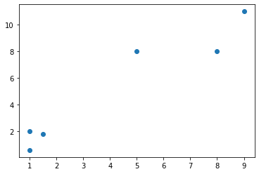

```python
data = pd.DataFrame([[1, 2], [5, 8], [1.5, 1.8], [8, 8], [1, 0.6],
              [9, 11]], columns=['x','y'])
print( data )

plt.scatter(data.x,data.y)
plt.show()
```

Рис. 3. Вручную созданные данные (точки)

##### Построение модели

Как и в случае с обучения с учителем, например, когда мы с вами работали с нейронными сетями в `TensorFlow`, вы сначала создаете модель, а затем вызываете метод запуска обучения `fit()`, используя свой источник данных. Теперь модель заполнена центроидами и метками. К ним можно получить доступ через свойства `cluster_centers_` и `labels_` соответственно.

```python
kmeans = KMeans(n_clusters=2).fit(data.values)

centroids = kmeans.cluster_centers_
labels = kmeans.labels_

print(centroids) #выведет X Y центроидов
print(labels)
```

```
[[7.33333333 9.        ]
 [1.16666667 1.46666667]]
[1 0 1 0 1 0]
```

**Визуализация кластеров**

Напишем кд, который визуализирует кластеры, и крестами помечает их центры. Чтобы различать принадлежность точек к каждому кластеру, построим группы данных на отдельных осях (имеется в виду – виртуальных), а также зададим им ключевые слова, цвета и метки:

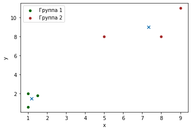

```python
data['labels'] = labels

group1 = data[data['labels']==1].plot( kind='scatter', x='x', y='y', color='DarkGreen', label="Группа 1" )
group2 = data[data['labels']==0].plot( kind='scatter', x='x', y='y', color='Brown', ax=group1, label="Группа 2" )

plt.scatter(centroids[:, 0],centroids[:, 1], marker = "x")
plt.show()
```

Рис. 4. Кластеры и их центры

K–Means также имеет метод `predict()`, который можно использовать для прогнозирования метки для наблюдения.

```python
print ('Предсказание для точки (3,3):')
kmeans.predict([[3,3]])[0]
```

```
Предсказание для точки (3,3):
```

```
1
```

### Линейная регрессия

Регрессия прогнозирует непрерывные выходы значений, а классификация – дискретные. Например, прогнозирование стоимости дома в долларах является проблемой регрессии, тогда как прогнозирование злокачественной или доброкачественной опухоли – проблемой классификации.

Термин «линейность» в алгебре относится к линейной зависимости между двумя или более переменными. Если мы отобразим это соотношение в двухмерном пространстве (в данном случае между двумя переменными), мы получим прямую линию.

Давайте рассмотрим код, в котором мы определим линейную зависимость между количеством часов, которые студент учится, и процентом оценок, которые студент получает на экзамене. Если мы нанесем независимую переменную «часы» на ось x, а зависимую переменную «оценка» на ось y, линейная регрессия даст нам прямую линию, которая наилучшим образом соответствует точкам данных, как это показано на рисунке ниже (Рис. 5).

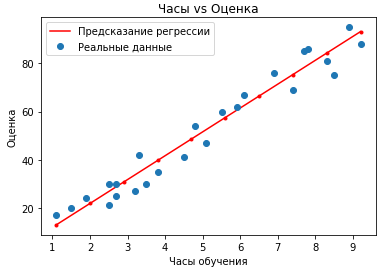

Рис. 5. Пример линейной регрессии

Известно из школьного курса математики, что уравнение прямой имеет вид y=kx+b, где: b – точка пересечения, а k – коэффициент наклона прямой линии. Данное уравнение представляет собой двумерный пример линейной регрессии. И в данном случае алгоритм линейной регрессии дает нам наиболее оптимальное значение для точки пересечения и наклона (в двух измерениях).

Переменные y и x остаются неизменными, поскольку они являются функциями данных и не могут быть изменены. Значения, которые мы можем контролировать – это точка пересечения и наклон. В зависимости от значений точки пересечения и наклона, может быть, несколько прямых линий.

По сути, алгоритм линейной регрессии производит вычисление уравнений с разными параметрами и возвращает те параметры наклона и сдвига, с которыми достигается наименьшая ошибка.

Эту же концепцию можно распространить на случаи, когда существует более двух переменных. Это называется множественной линейной регрессией. Например, необходимо спрогнозировать цену дома на основе его площади, количества спален, среднего дохода людей в этом районе, возраста дома и т.д. В этом случае зависимая переменная зависит от нескольких независимых переменных. Модель регрессии, включающая несколько переменных выражается представленной ниже формулой (формула 34):

| $$y\ = \ b_{0}\ + \ x_{1}b_{1}\ + \ x_{2}b_{2}\ + \ x_{3}b_{3}\ + \ldots + \ x_{n}b_{n}$$ | (34) |
| --- | --- |

где: *b*<sub>0</sub>–единственный член (коэффициент), n – количество зависимых параметров *x* (и их коэффициентов *b*).

Это уравнение гиперплоскости. Модель линейной регрессии в двух измерениях – это прямая линия, в трех измерениях – это плоскость, а в более чем трех измерениях – гиперплоскость.

Вернёмся, к примеру с оценками и временем обучения студенту – т.е. к двумерной линейной регрессии. В этой задаче мы спрогнозируем процент оценок, которые, как ожидается, получит студент, на основе количества часов, которые он изучил. Так как модули `pandas` и `matplotlib` мы уже подключали при работе с методом k–средних, то можем приступить сразу к открытию и визуализации исходных данных.

##### Набор данных

Нам необходим датасет `student_scores.csv`, содержащий оценки студента (если он вам недоступен совместно с архивом файлов данной книги, то скачать данный датасет можно по url: https://www.kaggle.com/kamleshsam/student-scores) . Когда мы убедились в наличии данного файла в текущем каталоге, то откроем его с помощью `pandas`, выведем его размерность (пункт 1 вывода) и первые три записи из него (пункт 2). Так же важно посмотреть на статистические детали данных – в частности, например, минимальные и максимальные значения – чтобы приблизительно понимать диапазоны значений (пункт 3).

```python
dataset = pd.read_csv('./student_scores.csv')
print ('1)shape', dataset.shape)
print ('2)head(3):\n',dataset.head(3))
print ('3)describe():\n',dataset.describe())
```

```
1)shape (25, 2)
2)head(3):
    Hours  Scores
0    2.5      21
1    5.1      47
2    3.2      27
3)describe():
            Hours     Scores
count  25.000000  25.000000
mean    5.012000  51.480000
std     2.525094  25.286887
min     1.100000  17.000000
25%     2.700000  30.000000
50%     4.800000  47.000000
75%     7.400000  75.000000
max     9.200000  95.000000
```

Давайте отобразим наши точки данных на двухмерном графике для того, чтобы взглянуть на наш набор данных визуально и посмотреть, сможем ли мы вручную найти какую–либо зависимость между данными:

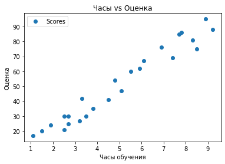

```python
dataset.plot(x='Hours', y='Scores', style='o') #style='o' - чтобы рисовалась точка, а не линия от прошлой точки к текущей
plt.title('Часы vs Оценка')
plt.xlabel('Часы обучения')
plt.ylabel('Оценка')
plt.show()
```

Рис. 6. Датасет (оценки в зависимости от часов обучения)

Из выведенного кодом графика мы можем увидеть, что существует некая линейная зависимость между количеством изученных часов и процентом набранных баллов.

##### Подготовка данных

Теперь у нас есть представление о наших данных. Следующим шагом является разделение данных на «атрибуты» и «метки». Атрибуты – это независимые переменные, а метки – это зависимые переменные, значения которых должны быть предсказаны.

В нашем наборе данных всего два столбца. Мы хотим предсказать оценку в зависимости от изученных часов. Поэтому наш набор атрибутов будет состоять из столбца «Часы», а меткой будет столбец «Оценка». Чтобы извлечь атрибуты и метки, выполним следующий код:

```python
X = dataset.iloc[:, :-1].values #последний столбец, т.е. оценки
y = dataset.iloc[:, 1].values #первый столбец, т.е. часы
```

Теперь атрибуты хранятся в переменной `X`, а переменная `Y` содержит метки. Напоминаем, что «`:`» – это знак среза, и т.к. не указано индексов, то в срез поподут все строки. Индекс «`-1`» – это первый с конца элемент, или последний столбец, и по до него не включительно мы сделали срез[5].

[5] ☝🙂 Это тоже самое, что, если бы просто взяли столбец с нулевым индексом. Но «`dataset.iloc[:, 0].values»` вернет «`[…,…,…]`», а «`dataset.iloc[:, :-1].values`» вернет «`[[…],[…],[…]]`» – и нам такая форма как раз и нужна. Поэтому сделано так, в целях краткости кода.

Теперь, когда у нас есть атрибуты и метки, следующим шагом будет разделение этих данных на обучающий и тестовый наборы. Мы сделаем это с помощью встроенного в `scikit-learn` метода `train_test_split()`[6]:

[6] ☝🙂 Метод `train_test_split()` случайным образом разбивает данные на обучающие и тестовые наборы, и такие разбиения каждый новый раз будут отличаться.

```python
from sklearn.model_selection import train_test_split
X_train, X_test, y_train, y_test = train_test_split(X, y, test_size=0.2, random_state=0)
```

Приведенный выше код разделяет: 80% данных – на обучающий набор, а 20% данных – на тестовый. Именно параметр `test_size` используется для задания соотношения обучающего и тестировочного набора.

##### Обучение

Для импорта модели линейной регресии и запуска машинного обучения выполним следующий код:

```python
from sklearn.linear_model import LinearRegression

regressor = LinearRegression()
regressor.fit(X_train, y_train);
```

При помощи `scikit-learn` очень просто реализовать модели линейной регрессии, поскольку все, что необходимо сделать, это импортировать класс `LinearRegression`, создать его экземпляр и вызвать метод `fit()`, передав ему обучающую выборку.

Модель линейной регрессии в ходе своего обучения найдет наилучшее значение для коэффициента сдвига и наклона, с которыми уравнение прямой, наилучшим образом соответствует данным. Чтобы увидеть значение точки пересечения и наклона, вычисленное алгоритмом линейной регрессии для нашего набора данных, выполним следующий код.

```python
print("Смещение (значение точки пересечения): ", regressor.intercept_)
print("Коэффициент наклона: ",regressor.coef_[0])
```

```
Смещение (значение точки пересечения):  2.018160041434662
Коэффициент наклона:  9.91065648064224
```

Подставив эти значения в уравнение прямой, станет возможным сравнить результаты с исходными данными, но мы сделаем это немного позже – на этапе, когда построим график предсказаний в сравнении с графиком реальных данных.

##### Прогнозы

Теперь, когда мы обучили модель, пришло время протестировать её и сделать некоторые прогнозы. Для этого мы воспользуемся нашими тестовыми данными и посмотрим, насколько точно наш алгоритм предсказывает оценку. Чтобы сделать прогнозы на тестовых данных, выполним код, представленный ниже:

```python
#Y_pred – это массив numpy, который содержит все предсказанные значения для входных значений в серии X_test.
y_pred = regressor.predict(X_test)

df = pd.DataFrame({'Действительное': y_test, 'Предсказанное': y_pred})
df
print (df)
```

```
   Действительное  Предсказанное
0              20      16.884145
1              27      33.732261
2              69      75.357018
3              30      26.794801
4              62      60.491033
```

Наша модель не очень точна, но всё же прогнозируемые оценки близки к фактическим. Визуализируем предсказания в сравнении с реальными данными при помощи кода, представленного ниже.

В данном коде вместо тестовых данных мы сгенерируем 10 дискретных значений часов, при этом минимальным часом будет являться такое же минимальное количество часов, сколько и исходном датасете. Соответственно так же и с максимальным.

Сейчас для вывода прямой предсказаний линейной регрессии нам не обязательно использовать именно тестовые данные, так как тестовые данные нужны для оценки точности модели, а на текущем этапе мы пока что посмотрим на визуальное представление предсказаний и реальных данных. К математической оценке точности мы перейдем позже.

```
   Hours     Scores
0    1.1  12.919882
1    2.0  21.839473
2    2.9  30.759064
Коэфициенты: [9.91065648] независимый член 2.018160041434662
Т.е. в одномерном случае y=kx+b: y=9.91065648064224*x+2.018160041434662
Например см. 1 строчку предсказаний y=9.91*1.1+2.02= 12.919
```

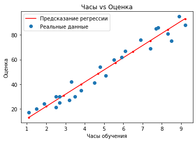

```python
import numpy as np

min=dataset['Hours'].min(); max=dataset['Hours'].max()
x_tests=np.linspace(min, max, 10) #сгенерируем 10 точек для предсказания
x_tests=x_tests.reshape(-1, 1) # из [] в [[]]
predict_values=pd.DataFrame( {'Hours': x_tests.reshape(-1), 'Scores':regressor.predict(x_tests)} )
print(predict_values.head(3)) #выведем первые 3 предсказания
ax = predict_values.plot(x='Hours', y='Scores', color='r', style='.-', label='Предсказание регрессии')
print("Коэфициенты:", regressor.coef_,'независимый член', regressor.intercept_)
print("Т.е. в одномерном случае y=kx+b: y=",regressor.coef_[0],'*x+', regressor.intercept_, sep='')
print("Например см. 1 строчку предсказаний y=9.91*1.1+2.02=",9.91*1.1+2.018)

dataset.plot(ax=ax, x='Hours', y='Scores', style='o', label='Реальные данные') #style='o' - чтобы рисовалась точка, а не линия от прошлой точки к текущей
plt.title('Часы vs Оценка'); plt.xlabel('Часы обучения'); plt.ylabel('Оценка')
plt.show()
```

##### Оценка алгоритма (Коэффициент детерминации, или R<sup>2</sup>)

Последний шаг – оценить алгоритм. Этот шаг особенно важен для сравнения того, насколько хорошо разные алгоритмы работают с конкретным набором данных. Для оценки алгоритмов регрессии обычно используются три уже рассмотренных ранее метрики в разделе «Ошибки (MSE, RMSE и MAE)» занятия «ЗАНЯТИЕ 11. TensorFlow Keras. Решение математических задач», но также важным показателем является R<sup>2</sup> (R–квадрат, или коэффициент детерминации).

Коэффициент детерминации – это доля дисперсии зависимой переменной, объясняемая рассматриваемой моделью. Т.е. если модель «объясняет», т.е. предсказывает, правильно все 100% возможных выходных значений, то коэффициент детерминации равен единице. Если же он равен 0, это означает, что связь между переменными регрессионной модели отсутствует, а если R<sup>2</sup> меньше нуля, то вместо модели для оценки значения выходной переменной будет более точным использование простого среднего ее наблюдаемых значений, т.е. модель выдает совершенно не правильные результаты – более неправильные, чем если бы это было среднее число. Обычно модель считается адекватной при коэффициенте детерминации равном 0.9 и выше.

Давайте выведем и проанализируем все 4 метрики. Для этого в `scikit-learn` доступен модуль `metrics`:

```python
from sklearn import metrics
print('Mean Absolute Error:', metrics.mean_absolute_error(y_test, y_pred))
print('Mean Squared Error:', metrics.mean_squared_error(y_test, y_pred))
print('Root Mean Squared Error:', np.sqrt(metrics.mean_squared_error(y_test, y_pred)))
print('r2_score: ', metrics.r2_score(y_test,y_pred))
```

```
Mean Absolute Error: 4.183859899002982
Mean Squared Error: 21.598769307217456
Root Mean Squared Error: 4.647447612100373
r2_score:  0.9454906892105354
```

Мы видим, что значение корня из среднеквадратичной ошибки (т.е. RMSE) составляет 4,64, что составляет менее 10% от среднего значения оценок всех студентов, т.е. 51,48 (его мы узнали в самом начале при открытии датасета). Это означает, что наш алгоритм имеет неплохую точность.

Мы изучили линейную регрессию с участием двух переменных. Почти все проблемы реального мира, с которыми вы столкнетесь, будут иметь более двух переменных. Для решения подобных задач применяется множественная линейная регрессия, т.е. множественной называют линейную регрессию, в модели которой число независимых переменных две или более. Отличие между простой и множественной линейной регрессией заключается в том, что вместо линии регрессии в ней используется гиперплоскость (как уже было сказано).

Преимущество множественной линейной регрессии[7] по сравнению с простой заключается в том, что использование в модели нескольких входных переменных позволяет увеличить долю объяснённой дисперсии выходной переменной, и таким образом улучшается точность модели. Т.е. при добавлении в модель каждой новой переменной коэффициент детерминации растёт.

[7] ☝🙂 Попробовать поработать с множественной регрессией вы можете на основе материала, доступного по url: https://stackabuse.com/linear-regression-in-python-with-scikit-learn. Датасет для него можно скачать тут: https://www.kaggle.com/harinir/petrol-consumption.

#### Деревья решений (decision tree)

Использование деревьев решений для прогнозного анализа имеет ряд преимуществ:

1. Деревья решений могут быть использованы для прогнозирования как непрерывных, так и дискретных значений, т. е. они хорошо работают как для задач регрессии, так и для задач классификации.
2. Они требуют относительно меньших усилий для обучения алгоритма.
3. Они могут быть использованы для классификации нелинейно разделимых данных.
4. Они очень быстры и эффективны по сравнению с другими алгоритмами классификации.

Дерево решений – это один из наиболее часто и широко используемых алгоритмов контролируемого машинного обучения, который может выполнять как регрессионные, так и классификационные задачи. «Интуиция» (логика), лежащая в основе алгоритма дерева решений, проста, но в то же время очень мощна.

Для каждого атрибута в наборе данных алгоритм дерева решения формирует узел, где наиболее важный атрибут помещается в корневой узел (т.е. остается в текущем узлу как готовое решение). Если условие корневого узла не выполняется, то данные переходят в следующий узел и это продолжается до тех пор, пока не будет достигнут конечный узел, так же содержащий предсказание или результат дерева решений.

Дерево решений для вышеупомянутого сценария выглядит представленным на рисунке ниже образом (Рис. 7).

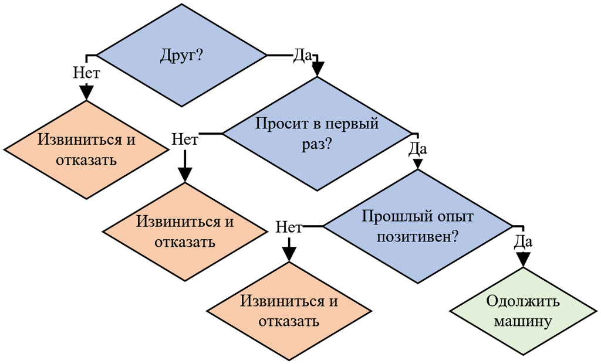

Рис. 7. Дерево решений

Последовательность работы с деревьями решений для классификации и регрессии в `Scikit-Learn` аналогична списку действий, которые были выполнены и с другими рассмотренными ранее алгоритмами.

Сначала мы загрузим наш датасет, затем мы инициализируем наше дерево решений для классификации. Далее запустим обучение при помощи метода `fit()`, передав ему обучающую выборку и протестируем работу модели.

В качестве набора данных будет использован датасет ирисов Фишера. Данный датасет встроен в библиотеку `scikit-learn` в виду того, что является академическим – аналогично с тем, как ранее рассмотренный датасет `MNIST`, встроенный в `TensorFlow`.

Ирисы Фишера состоят из данных о 150 экземплярах ириса, по 50 экземпляров из трёх видов:

- ирис щетинистый (`iris setosa`);
- ирис виргинский (`iris virginica`);
- ирис разноцветный (`iris versicolor`).

Для каждого экземпляра измерены четыре характеристики (в сантиметрах):

1. Длина наружной доли околоцветника (`sepal length`);
2. Ширина наружной доли околоцветника (`sepal width`);
3. Длина внутренней доли околоцветника (`petal length`);
4. Ширина внутренней доли околоцветника (`petal width`).

Подключим все необходимые модули, загрузим датасет и обучим модель:

```python
from sklearn.datasets import load_iris
from sklearn.tree import DecisionTreeClassifier, plot_tree

# Загрузить данные
iris = load_iris()

#создадим и обучим классификатор на основе дерева решений
clf = DecisionTreeClassifier()
clf = clf.fit(iris.data, iris.target)
```

`Scikit-learn` позволяет визуализировать дерево решений. Для этого есть несколько настраиваемых опций, которые помогут визуализировать узлы принятия решений и разбить изученную модель, что очень полезно для понимания того, как она работает. Ниже мы раскрасим узлы на основе имен признаков и отобразим информацию о классе и объектах каждого узла.

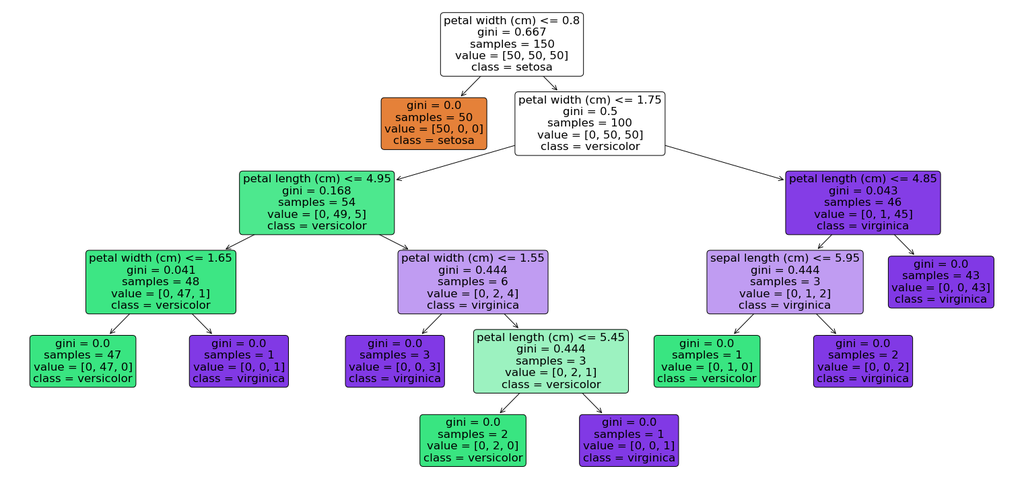

```python
plt.figure(figsize=((27, 13)))
plot_tree(
    clf,
    filled=True,
    feature_names=iris.feature_names,
    class_names=iris.target_names,
    rounded=True,)
plt.show()
```

Рис. 8. Дерево решений (классификация ирисов)

Обратите внимание на коэфициент Джини (`gini`) на рисунке из вывода примера выше. Коэффициент Джини – это статистический показатель степени расслоения по какому–либо изучаемому признаку. Измеряет степень или вероятность того, что конкретная переменная будет неправильно классифицирована (не удовлетворит условию), когда она выбрана случайным образом. Коэффициент Джини лежит в диапазоне от 0 до 1, а если он равен 0.5, то значит элементы распределены (распределяются) равномерно на классы.

Например, посмотрите на самый верхний узел – у него `gini=0.667`. Если объяснять графически, то это означает, что 33% (`samples=50`) элементов распределяются влево, а остальные 67% (`samples=100`) – вправо. Имеется в виду, что `samples=150` корневого узла разделяется в пропорции 0,667. И так же далее аналогично происходит подобное на каждом узле.

Построим поверхность принятия решений дерева решений, обученного парам характеристик ирисов. Всего 4 характеристики, значит попарных сочетаний без повторений будет 6. Для каждой пары характеристик цветка модель изучает границы решения, состоящие из комбинаций простых пороговых правил, выведенных из обучающих выборок.

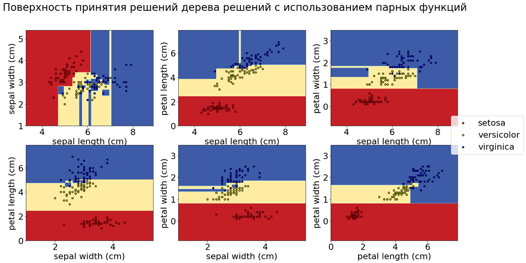

```python
# параметры
n_classes = 3
plot_colors = "ryb"
plot_step = 0.02

plt.rcParams["figure.figsize"] = (20,10)
plt.rcParams.update({'font.size': 22})

for pairidx, pair in enumerate([[0, 1], [0, 2], [0, 3], [1, 2], [1, 3], [2, 3]]):
    # Мы берем только две соответствующие оси
    X = iris.data[:, pair]
    y = iris.target

    # Обучение
    clf_pair = DecisionTreeClassifier().fit(X, y)

    # Построение границы решений
    plt.subplot(2, 3, pairidx + 1)

    x_min, x_max = X[:, 0].min() - 1, X[:, 0].max() + 1
    y_min, y_max = X[:, 1].min() - 1, X[:, 1].max() + 1
    xx, yy = np.meshgrid( #генерация точек, которые распределены как сетка
        np.arange(x_min, x_max, plot_step), np.arange(y_min, y_max, plot_step)
    )

    Z = clf_pair.predict(np.c_[xx.ravel(), yy.ravel()]) #ravel()- сделать массив плоским
    Z = Z.reshape(xx.shape)
    cs = plt.contourf(xx, yy, Z, cmap=plt.cm.RdYlBu) #z- значение высоты на которой рисуется контур

    plt.xlabel(iris.feature_names[pair[0]])
    plt.ylabel(iris.feature_names[pair[1]])

    # Построение точек обучения
    for i, color in zip(range(n_classes), plot_colors):
        idx = np.where(y == i)
        plt.scatter(
            X[idx, 0],
            X[idx, 1],
            c=color,
            label=iris.target_names[i],
            edgecolor="black",
            s=20, #размер маркера
        )

plt.suptitle("Поверхность принятия решений дерева решений с использованием парных функций")
plt.legend(bbox_to_anchor=(1.55, 1.35)) #отобразить названия классов правее
```

Рис. 9. Поверхность принятия решений с использованием парных функций

На поверхности принятия решения цветами закрашены области кластеризации. Видно, что они вполне однозначны и по данной поверхности можно достаточно удобно по сочетанию двух признаков определить к какому кластеру относится цветок с теми или иными двумя признаками.

Закрепим полученное понимание, и для этого выведем сколько в последней паре элементов в каждом кластере. Отметим, что вы их можете посчитать на поверхности принятия решений, но по факту больше половины парных значений повторяются – есть даже те, что повторяются 8 раз (а всего, напомним, в датасете по 50 цветов в каждом из 3 классов) и поэтому на поверхности принятия решений вы их не увидите (перекроют друг друга).

Как итог, выведем не только обычное количество элементов в кластере последней пары, но и выведем, например, количество уникальных `setosa` в этой паре. Сравните полученное значение 22 с поверхностью принятия решений, методом подсчета точек на 6–ой диаграмме.

```python
y_pred_last= clf_pair.predict(iris.data[:, pair]) #получим предсказания для последней пары

setosa_unique=len(np.unique(iris.data[:50, pair], return_counts=True, axis=0)[1]) #посчитаем уникальные строки с даннами характеристиками

print ('В последней паре у кластеров столько элементов:')
print ('0)setosa',(y_pred_last==0).sum(), ', но по факту уникальных только', setosa_unique, 'см. кол-во setosa на 6ом графике' )
print ('1)versicolor',(y_pred_last==1).sum())
print ('2)virginica',(y_pred_last==2).sum())
```

```
В последней паре у кластеров столько элементов:
0)setosa 50 , но по факту уникальных только 22 см. кол-во setosa на 6ом графике
1)versicolor 49
2)virginica 51
```

Обратите внимание, что имеются расхождения по количеству цветов в кластерах – должно было быть по 50шт. в каждом кластере, как и в исходном датасете:

```python
print (np.unique(iris.target, return_counts=True, axis=0))
print ('[индексы кластеров], [колличество элементов в кластерах]')
```

```
(array([0, 1, 2]), array([50, 50, 50], dtype=int64))
[индексы кластеров], [колличество элементов в кластерах]
```

Это вызвано тем, что мы обучали модель только 6–ой парой характеристик. Ранее упоминалось, что чем больше различных параметров, тем выше сходимость модели и её коэффициент детерминации (`r2_score`). Давайте проверим это. Ниже мы выведем ошибки для модели, обученной только 6–ой парой, и для модели, обученной всеми параметрами.

```python
print('При обучении только по 6 паре характеристик, есть небольшая ошибка кластеризации:')
print('(имеется в виду при проверке всем датасетом)')
print('Mean Absolute Error:', metrics.mean_absolute_error(iris.target, y_pred_last))
print('Mean Squared Error:', metrics.mean_squared_error(iris.target, y_pred_last))
print('Root Mean Squared Error:', np.sqrt(metrics.mean_squared_error(iris.target, y_pred_last)))
print('r2_score: ', metrics.r2_score(iris.target, y_pred_last))

y_pred_all= clf.predict(iris.data) #получим предсказания для всех данных
print('\nПри обучении на всех данных, ошибок кластеризации, как ни странно, нет:')
print('Mean Absolute Error:', metrics.mean_absolute_error(iris.target, y_pred_all))
print('Mean Squared Error:', metrics.mean_squared_error(iris.target, y_pred_all))
print('Root Mean Squared Error:', np.sqrt(metrics.mean_squared_error(iris.target, y_pred_all)))
print('r2_score: ', metrics.r2_score(iris.target,y_pred_all))
```

```
При обучении только по 6 паре характеристик, есть небольшая ошибка кластеризации:
(имеется в виду при проверке всем датасетом)
Mean Absolute Error: 0.006666666666666667
Mean Squared Error: 0.006666666666666667
Root Mean Squared Error: 0.08164965809277261
r2_score:  0.99

При обучении на всех данных, ошибок кластеризации, как ни странно, нет:
Mean Absolute Error: 0.0
Mean Squared Error: 0.0
Root Mean Squared Error: 0.0
r2_score:  1.0
```

Действительно – мы видим, что при обучении с использованием всех параметров точность модели выше (в частности, обратите внимание на коэфициент детерминации `r2_score`). В данном случае точность абсолютна – нет ошибок предсказаний. Это выглядит очень странно, но подтверждается информацией из сети Интернет – дерево решений обучается на датасете ирисов очень точно.

Т.к. коэффициент детерминации, который является долей объяснённых дисперсий, равен 1, значит все дисперсии объяснены.

Но мы обучали и оценивали модель на одних и тех же данных – хорошо, она всем им обучилась и решила правильно. Но грамотным подходом при оценивании является оценивание при помощи новых данных, т.е. при помощи тестовой выборки, как мы уже и рассматривали это ранее в примере линейной регрессии:

```python
X_train, X_test, y_train, y_test = train_test_split(iris.data, iris.target, test_size=0.2, random_state=0)
clf = DecisionTreeClassifier()
clf = clf.fit(X_train, y_train)

y_pred_all= clf.predict(X_test) #получим предсказания для всех данных
print('\nПри обучении на 80% данных, и тесте на 20% - ошибок все равно нет:')
print('Mean Absolute Error:', metrics.mean_absolute_error( y_test, y_pred_all))
print('Mean Squared Error:', metrics.mean_squared_error( y_test, y_pred_all))
print('Root Mean Squared Error:', np.sqrt(metrics.mean_squared_error( y_test, y_pred_all)))
print('r2_score: ', metrics.r2_score( y_test,y_pred_all))
```

```
При обучении на 80% данных, и тесте на 20% - ошибок все равно нет:
Mean Absolute Error: 0.0
Mean Squared Error: 0.0
Root Mean Squared Error: 0.0
r2_score:  1.0
```

Теперь точно все сделано правильно. Видимо мы сделали правильный вывод – модель очень точна, даже, на первый взгляд – пугающе точна, совсем нет ошибок, даже минимальных. Но они появятся, если, например, изменить соотношение тестовой и обучающей выборки.

## Контрольные задания и вопросы

1. Опишите какие возможности предоставляет библиотека `Scikit-learn`. Чем схожа и чем отличается с `TensorFlow`.
2. Кластерный анализ – что такое и где применяется, чем отличается от классификации.
3. Линейная регрессия – проведите эксперимент с собственным датасетом (к примеру, подготовьте в `Excel` датасет случайных значений, лежащих возле какого–либо уравнения).
4. Проведите и проанализируйте свои собственные эксперименты с К–средних и деревом решений.